# Exploratory Data Analysis of Titanic Dataset

### July 2019

```python
import pandas as pd
import numpy as np
import matplotlib.pyplot as plt
import seaborn as sn
```

```python
titanic_df=pd.read_csv("titanic.csv")
```

### Viewing the data

```python
titanic_df.shape
```

```
(1313, 11)
```

*The dataframe has 1313 rows and 11 features*

```python
titanic_df.info();
```

```
<class 'pandas.core.frame.DataFrame'>
RangeIndex: 1313 entries, 0 to 1312
Data columns (total 11 columns):
row.names    1313 non-null int64
pclass       1313 non-null object
survived     1313 non-null int64
name         1313 non-null object
age          633 non-null float64
embarked     821 non-null object
home.dest    754 non-null object
room         77 non-null object
ticket       69 non-null object
boat         347 non-null object
sex          1313 non-null object
dtypes: float64(1), int64(2), object(8)
memory usage: 112.9+ KB
```

*Do not believe the type of the objects which this summary shows. The datatypes can be off a lot of times. It helps to visually inspect your data to determine whether the types are correct*

**Let us view some of the data from the dataframe. It is a really important step in EDA to look at the top and the bottom of your dataset , to assess some of the data challenges**

```python
titanic_df.head(5)
```

|  | row.names | pclass | survived | name | age | embarked | home.dest | room | ticket | boat | sex |
| --- | --- | --- | --- | --- | --- | --- | --- | --- | --- | --- | --- |
| 0 | 1 | 1st | 1 | Allen, Miss Elisabeth Walton | 29.0000 | Southampton | St Louis, MO | B-5 | 24160 L221 | 2 | female |
| 1 | 2 | 1st | 0 | Allison, Miss Helen Loraine | 2.0000 | Southampton | Montreal, PQ / Chesterville, ON | C26 | NaN | NaN | female |
| 2 | 3 | 1st | 0 | Allison, Mr Hudson Joshua Creighton | 30.0000 | Southampton | Montreal, PQ / Chesterville, ON | C26 | NaN | (135) | male |
| 3 | 4 | 1st | 0 | Allison, Mrs Hudson J.C. (Bessie Waldo Daniels) | 25.0000 | Southampton | Montreal, PQ / Chesterville, ON | C26 | NaN | NaN | female |
| 4 | 5 | 1st | 1 | Allison, Master Hudson Trevor | 0.9167 | Southampton | Montreal, PQ / Chesterville, ON | C22 | NaN | 11 | male |

```python
titanic_df.tail()
```

|  | row.names | pclass | survived | name | age | embarked | home.dest | room | ticket | boat | sex |
| --- | --- | --- | --- | --- | --- | --- | --- | --- | --- | --- | --- |
| 1308 | 1309 | 3rd | 0 | Zakarian, Mr Artun | NaN | NaN | NaN | NaN | NaN | NaN | male |
| 1309 | 1310 | 3rd | 0 | Zakarian, Mr Maprieder | NaN | NaN | NaN | NaN | NaN | NaN | male |
| 1310 | 1311 | 3rd | 0 | Zenn, Mr Philip | NaN | NaN | NaN | NaN | NaN | NaN | male |
| 1311 | 1312 | 3rd | 0 | Zievens, Rene | NaN | NaN | NaN | NaN | NaN | NaN | female |
| 1312 | 1313 | 3rd | 0 | Zimmerman, Leo | NaN | NaN | NaN | NaN | NaN | NaN | male |

*We can see observe that there are quite a few NaNs that appear in the dataset*

## Answer some questions , maybe?

### How many people survived?

```python
titanic_df.survived.value_counts(normalize=True)*100
```

```
0    65.803503
1    34.196497
Name: survived, dtype: float64
```

*We can observe that only 34% of the people survived. Remember that percentages always makes sense instead of absolute values*

### Was there any particular gender that was prominent among survivors?

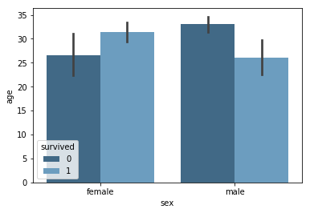

```python
sn.barplot(x="sex", y="age", hue= 'survived',data=titanic_df,palette="Blues_d");
```

```python
np.round(pd.crosstab(titanic_df.survived,titanic_df.sex, margins=True,normalize="index"),2)
```

| sex survived | female | male |
| --- | --- | --- |
| 0 | 0.18 | 0.82 |
| 1 | 0.68 | 0.32 |
| All | 0.35 | 0.65 |

### Did the first class have an advantage over other classes in survival figures?

```python
np.round(pd.crosstab(titanic_df.pclass,titanic_df.survived,normalize="columns"),2)
```

| survived pclass | 0 | 1 |
| --- | --- | --- |
| 1st | 0.15 | 0.43 |
| 2nd | 0.19 | 0.27 |
| 3rd | 0.66 | 0.31 |

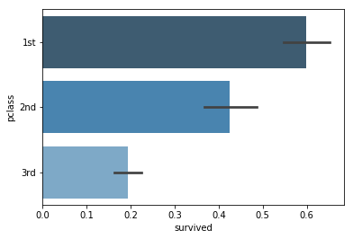

```python
sn.barplot(x="survived", y="pclass",data=titanic_df,palette="Blues_d");
```

### People of what ages were onboard the ship ?

**What was the minimum age**

```python
titanic_df.age.min()
```

```
0.1667
```

**What was the maximum age?**

```python
titanic_df.age.max()
```

```
71.0
```

**Visualise the distribution of age**

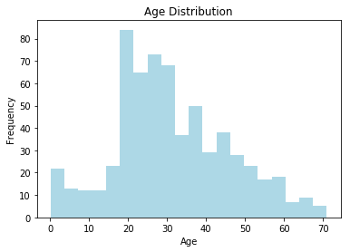

```python
plt.hist(titanic_df.age.dropna(),bins=20,color='lightblue');
plt.xlabel("Age");
plt.ylabel("Frequency");
plt.title("Age Distribution");
```

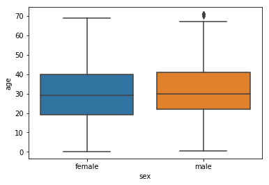

```python
sn.boxplot(x="sex", y="age",data=titanic_df);
```

### Average age of people in the various classes and their survival rates

```python
titanic_df.groupby('pclass')['age'].mean()
```

```
pclass
1st    39.667773
2nd    28.300314
3rd    24.519658
Name: age, dtype: float64
```

```python
pclass_sur_df=(titanic_df.groupby(['pclass','survived'])
               ['age'].mean().reset_index())

pclass_sur_df
```

|  | pclass | survived | age |
| --- | --- | --- | --- |
| 0 | 1st | 0 | 44.287356 |
| 1 | 1st | 1 | 36.776379 |
| 2 | 2nd | 0 | 31.672414 |
| 3 | 2nd | 1 | 24.225694 |
| 4 | 3rd | 0 | 25.666666 |
| 5 | 3rd | 1 | 20.804348 |

### How was the survival rate for children (age<=11)

```python
children_df=titanic_df[titanic_df.age<=11]
```

```python
titanic_df[titanic_df.age<=11]['survived'].value_counts(normalize=True)*100
```

```
1    68.0
0    32.0
Name: survived, dtype: float64
```

*Close to 68% of the children survived, which may imply the youngest have higher survival rates*